# Índice de Viviendas con Materialidad Precaria (IVMP) vs Nivel Educacional — Provincia de San Antonio

Juan Esteban Rodrigo Gallardo Palma

# 1. Introducción

La provincia de San Antonio, ubicada en la Región de Valparaíso, constituye un territorio donde convergen funciones portuarias, turísticas, residenciales y rurales. Está conformada por seis comunas San Antonio, Cartagena, El Tabo, El Quisco, Algarrobo y Santo Domingo, que presentan marcadas diferencias en su grado de urbanización, consolidación habitacional y desarrollo socioeconómico.

Durante las últimas décadas, la provincia ha experimentado un crecimiento urbano y poblacional heterogéneo, impulsado tanto por el aumento del área metropolitana de Valparaíso y San Antonio como por la crecida de la segunda residencia asociada al veraneo costero. Este proceso ha dado lugar a un territorio con fuertes contrastes espaciales; zonas costeras altamente urbanizadas con alta valorización del suelo, y sectores interiores con viviendas precarias, déficit de servicios básicos y menor nivel educativo.

En este contexto, el análisis de la materialidad de las viviendas y del nivel educacional de la población ofrece una aproximación para comprender la vulnerabilidad socio–territorial de la provincia.

El Indicador de Viviendas con Materialidad Precaria (IVMP) permite evaluar la calidad constructiva y el nivel de consolidación del hábitat, mientras que el porcentaje de personas con educación superior actúa como un intermediario del capital humano y del bienestar socioeconómico.

La relación entre ambas variables infraestructura residencial y educación refleja no solo la capacidad económica de los hogares, sino también su potencial de desarrollo social y su acceso a oportunidades dentro del territorio. La combinación espacial de estos indicadores mediante análisis bivariado permite identificar patrones de desigualdad estructural, delimitar zonas críticas y apoyar la toma de decisiones en planificación territorial, inversión pública y estrategias de desarrollo local.

## 1.2. Objetivo Específicos

- Identificar las comunas con mayores niveles de precariedad habitacional de la provincia.
- Calcular y representar el porcentaje de población con educación superior.
- Visualizar los patrones espaciales resultantes a través de un mapa bivariado e interpretar con enfoque de geomarketing social y urbano.

# 2. Desarrollo

## 2.1. Metodología

Para el desarrollo metodológico de este trabajo se utilizaron dos herramientas principales: pgAdmin y RStudio, con el objetivo de procesar, analizar y visualizar información proveniente del Censo de Población y Vivienda 2017 elaborado por el Instituto Nacional de Estadísticas (INE).

El análisis se centró en la Provincia de San Antonio, perteneciente a la Región de Valparaíso, considerando como unidad de análisis la zona censal urbana y rural. Esta escala intermedia permite observar diferencias intra–provinciales entre comunas costeras e interiores, evidenciando contrastes en la consolidación del espacio habitado, la distribución del capital humano y las condiciones materiales de las viviendas.

El enfoque metodológico tuvo como propósito calcular y representar indicadores socio–habitacionales relevantes desde una perspectiva territorial, orientados a caracterizar la vulnerabilidad estructural y social del hábitat provincial. Los indicadores seleccionados se construyeron a partir de:

1. **Indicador de Viviendas con Materialidad Precaria (IVMP)**: Porcentaje de viviendas ocupadas con materiales estructurales precarios, reflejando la calidad constructiva y las condiciones habitacionales de un territorio.
2. **Porcentaje de mayores de 18 años con educación media completa o superior**: representa el porcentaje de personas adultas (P09 > 18 años) que han alcanzado al menos el nivel de educación media completa o superior (P15 ≥ 7).

### 2.1.1. Librerías necesarias

Se inicia cargando las siguientes librerías para el posterior análisis:

```r
library(DBI)
library(RPostgres)
library(sf)
library(ggplot2)
library(cowplot)
library(biscale)
```

Estas librerías permiten establecer conexiones con bases de datos PostgreSQL, manejar geometrías espaciales (sf) y generar visualizaciones estadísticas y cartográficas.

### 2.1.2. Conexión a la base de datos PostgresSQL

Se establece una conexión con una base de datos local en PostgreSQL que contiene las tablas del Censo 2017 para la Región de Valparaíso.

```r
con <- dbConnect(
  Postgres(),
  dbname   = "censo_v_2017",
  host     = "localhost",
  port     = 5432,
  user     = "postgres",
  password = "postgres"
)
```

Variables consideradas:

*Respecto a vivienda*:

- P02 — Ocupación: 1 = con moradores presentes (filtro para IVMP).
- P03A — Material muros: 6 = materiales precarios (lata, cartón, plástico, etc.).
- P03B — Material techo: 6 = materiales precarios, 7 = sin cubierta sólida.
- P03C — Material piso: 4 = capa de cemento sobre tierra, 5 = tierra.

*Ámbito personas:*

- P09 — Edad (en años). Aquí se considera población adulta: P09 > 18.
- P15 — Nivel educacional alcanzado. Se usa P15 ≥ 7 = educación media completa o superior.

La consulta SQL genera la siguiente tabla con los indicadores y datos por zona censal.

[output not shown]

```r
sql_indicadores <- "
WITH agg AS (
  SELECT
    z.geocodigo::double precision AS geocodigo,
    c.nom_comuna,

    -- IVMP: % viviendas con materialidad precaria (muros OR techo OR piso)
    COALESCE(ROUND(
      COUNT(*) FILTER (
        WHERE v.p02 = 1 AND (
          v.p03a = 6 OR          -- muros: materiales precarios
          v.p03b IN (6,7) OR     -- techo: precarios o sin cubierta sólida
          v.p03c IN (4,5)        -- piso: capa de cemento sobre tierra / tierra
        )
      ) * 100.0 /
      NULLIF(COUNT(*) FILTER (WHERE v.p02 = 1), 0), 2), 0) AS ivmp,

    -- % personas mayores de 18 años con P15 >= 7 (media completa o superior)
    COALESCE(ROUND(
      COUNT(*) FILTER (WHERE p.p09 > 18 AND p.p15 >= 7) * 100.0 /
      NULLIF(COUNT(*) FILTER (WHERE p.p09 > 18), 0), 2), 0) AS edu_alta

  FROM public.personas   AS p
  JOIN public.hogares    AS h  ON p.hogar_ref_id    = h.hogar_ref_id
  JOIN public.viviendas  AS v  ON h.vivienda_ref_id = v.vivienda_ref_id
  JOIN public.zonas      AS z  ON v.zonaloc_ref_id  = z.zonaloc_ref_id
  JOIN public.comunas    AS c  ON z.codigo_comuna   = c.codigo_comuna
  JOIN public.provincias AS pr ON pr.provincia_ref_id = c.provincia_ref_id
  WHERE pr.nom_provincia = 'SAN ANTONIO'
  GROUP BY z.geocodigo, c.nom_comuna
)
SELECT
  geocodigo,
  nom_comuna,
  ivmp,
  edu_alta
FROM agg
ORDER BY ivmp DESC;
"

df_indicadores <- dbGetQuery(con, sql_indicadores)
```

Se extrae ademas la geometría que corresponde a las zonas urbanas de la Provincia de San Antonio desde la tabla dpa.zonas_censales_v. se seleccionan tanto urbano como rural.

```r
sql_geometria <- "
SELECT
  geocodigo::double precision AS geocodigo,
  geom
FROM dpa.zonas_censales_v
WHERE nom_provin = 'SAN ANTONIO';
"
sf_zonas <- st_read(con, query = sql_geometria, quiet = TRUE)
```

Luego se integra los datos censales que fueron procesados con la geometría espacial, generando una tabla espacial final lista para su visualización en siguientes procesos.

```r
sf_mapa <- merge(x = sf_zonas, y = df_indicadores, by = 'geocodigo', all.x = FALSE)
```

### 2.1.3. Indicadores

El análisis se centró en dos indicadores principales, que son capaces de representar condiciones estructurales del hábitat y dimensiones socioeducativas de la población:

1. Indicador de Viviendas con Materialidad Precaria (IVMP):

   Evalúa la proporción de viviendas ocupadas que presentan deficiencias en sus materiales constructivos muros, techumbre y pisos, asociados a condiciones de pobreza material y exposición a riesgos ambientales.

$$\text{IVMP} = \left( \frac{\text{Num viviendas con material
precario}}{\text{Total de viviendas}} \right) \times 100\$$

2. Porcentaje de población con educación superior (edu_alta):

## 2.2. Resultados y análisis

Este mapa muestra la distribución espacial del índice de viviendas con materialidad precaria (IVMP).

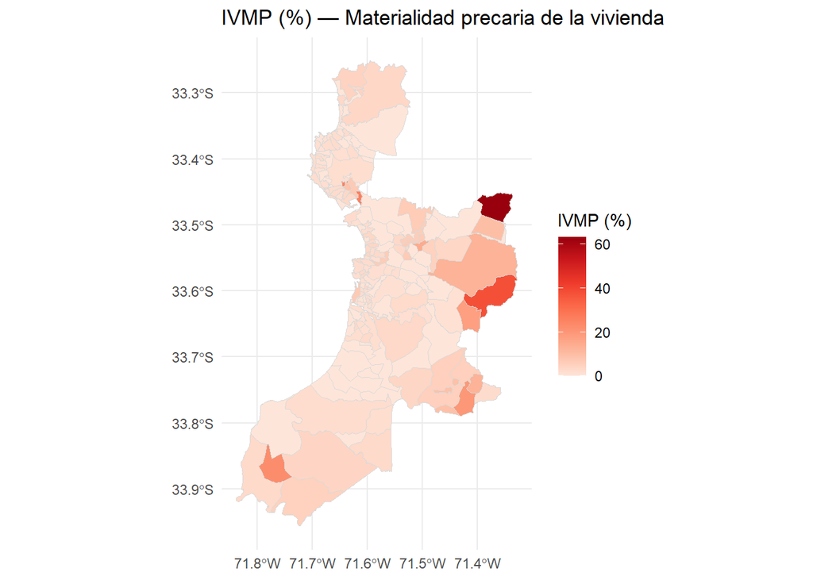

```r
map_ivmp <- ggplot(sf_mapa) +
  geom_sf(aes(fill = ivmp), color = 'gray85', size = 0.2) +
  scale_fill_distiller(palette = 'Reds', direction = 1) +
  labs(title = 'IVMP (%) — Materialidad precaria de la vivienda',
       fill  = 'IVMP (%)') +
  theme_minimal()
print(map_ivmp)
```

Los **tonos rojos** más intensos identifican las zonas donde existe mayor proporción de **viviendas con muros, techos o pisos de materiales inadecuados**, como cartón, plásticos o tierra.

En resumen, se evidencia un patrón territorial desigual: los sectores costeros y urbanos muestran mejores condiciones materiales, mientras que las áreas interiores y rurales concentran vulnerabilidad estructural. Esto responde a diferencias en ingresos, acceso a servicios urbanos y calidad de materiales de construcción.

El mapa educativo evidencia el porcentaje de adultos con al menos enseñanza media completa o superior.

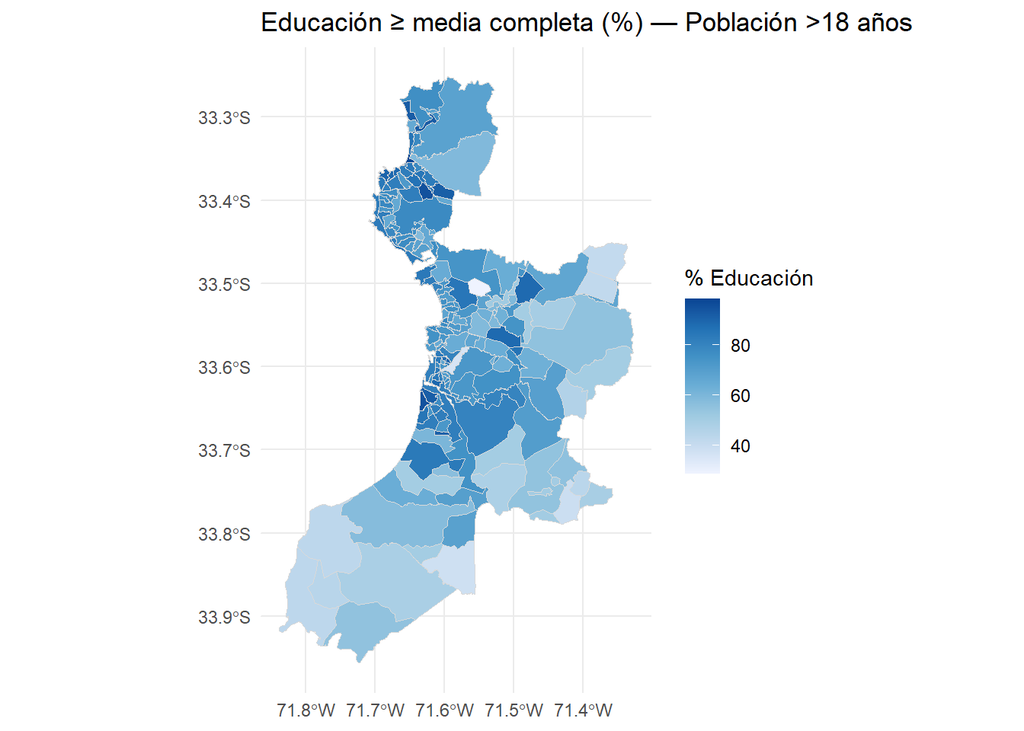

```r
map_edu <- ggplot(sf_mapa) +
  geom_sf(aes(fill = edu_alta), color = 'gray85', size = 0.2) +
  scale_fill_distiller(palette = 'Blues', direction = 1) +
  labs(title = 'Educación ≥ media completa (%) — Población >18 años',
       fill  = '% Educación') +
  theme_minimal()
print(map_edu)
```

En resumen, se evidencia una brecha entre costa e interior. Las zonas con más desarrollo económico y urbano muestran mejor formación educativa, lo que repercute directamente en la calidad de vida y oportunidad laboral.

El gráfico de dispersión permite visualizar la relación estadística entre precariedad habitacional y educación a nivel de zona censal.

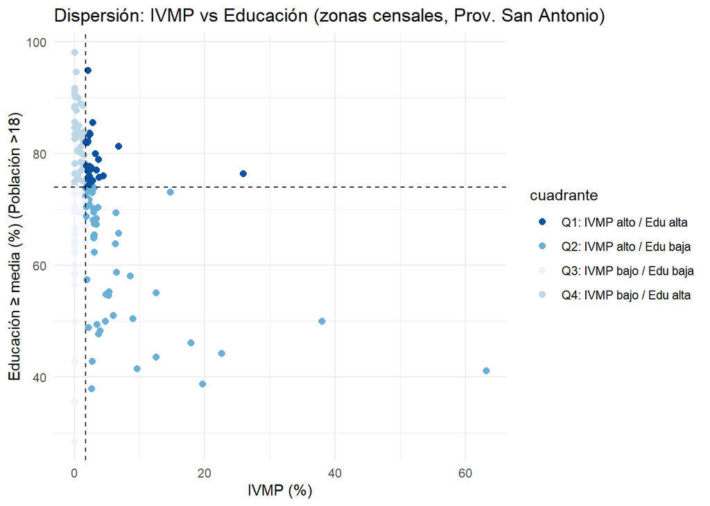

```r
mediana_ivmp <- median(sf_mapa$ivmp, na.rm = TRUE)
mediana_edu  <- median(sf_mapa$edu_alta, na.rm = TRUE)

sf_mapa$cuadrante <- with(sf_mapa, ifelse(
  ivmp >= mediana_ivmp & edu_alta >= mediana_edu, 'Q1: IVMP alto / Edu alta',
  ifelse(ivmp >= mediana_ivmp & edu_alta <  mediana_edu, 'Q2: IVMP alto / Edu baja',
         ifelse(ivmp <  mediana_ivmp & edu_alta <  mediana_edu, 'Q3: IVMP bajo / Edu baja',
                'Q4: IVMP bajo / Edu alta'))))

colores_cuadrantes <- c(
  'Q1: IVMP alto / Edu alta' = '#08519c',
  'Q2: IVMP alto / Edu baja' = '#6baed6',
  'Q3: IVMP bajo / Edu baja' = '#eff3ff',
  'Q4: IVMP bajo / Edu alta' = '#bdd7e7'
)

grafico_cuadrantes <- ggplot(sf_mapa, aes(x = ivmp, y = edu_alta, color = cuadrante)) +
  geom_point(size = 2) +
  geom_vline(xintercept = mediana_ivmp, linetype = 'dashed') +
  geom_hline(yintercept = mediana_edu,  linetype = 'dashed') +
  scale_color_manual(values = colores_cuadrantes) +
  labs(x = 'IVMP (%)',
       y = 'Educación ≥ media (%) (Población >18)',
       title = 'Dispersión: IVMP vs Educación (zonas censales, Prov. San Antonio)') +
  theme_minimal()

print(grafico_cuadrantes)
```

La mayoría de los puntos se concentran en IVMP bajos (0–10 %), con amplia variabilidad educativa (40–90 %).

La tendencia general indica que a medida que aumenta el nivel educacional, disminuye el IVMP, lo que sugiere una relación inversa entre ambas variables.

El gráfico refuerza el patrón observado en los mapas: la educación actúa como un factor protector frente a la precariedad habitacional. Las zonas con más adultos escolarizados tienden a presentar mejores condiciones materiales en la vivienda.

El mapa bivariado sintetiza espacialmente la relación conjunta entre educación y materialidad.

```r
sf_mapa_bi <- bi_class(
  sf_mapa,
  x = ivmp,
  y = edu_alta,
  dim = 3,
  style = 'jenks'
)

sql_comunas <- "
SELECT nom_comuna, geom
FROM dpa.comunas_v
WHERE nom_provin = 'SAN ANTONIO';
"
sf_comunas_sa <- st_read(con, query = sql_comunas, quiet = TRUE)

# CRS proyectado para evitar advertencias al generar centroides
crs_mapa <- st_crs(sf_mapa_bi)
sf_comunas_proj <- st_transform(sf_comunas_sa, 32719)
sf_centroides_proj <- st_point_on_surface(sf_comunas_proj)
sf_centroides <- st_transform(sf_centroides_proj, crs_mapa)

caja <- st_bbox(sf_mapa_bi)

mapa_bivariado_etiquetas <- ggplot() +
  geom_sf(data = sf_mapa_bi, aes(fill = bi_class), color = NA) +
  geom_sf(data = sf_comunas_sa, fill = NA, color = 'black', size = 0.3) +
  geom_sf_text(data = sf_centroides, aes(label = nom_comuna), size = 2.2, fontface = 'bold') +
  bi_scale_fill(pal = 'DkBlue', dim = 3) +
  labs(title = 'Mapa bivariado: IVMP vs Educación ≥ media (Población >18 años)',
       subtitle = 'Provincia de San Antonio') +
  coord_sf(xlim = c(caja['xmin'], caja['xmax']),
           ylim = c(caja['ymin'], caja['ymax']),
           expand = FALSE) +
  theme_void() +
  theme(plot.title = element_text(hjust = 0.5, face = 'bold'))

leyenda_bivariada <- bi_legend(
  pal = 'DkBlue', dim = 3,
  xlab = 'IVMP (bajo → alto)',
  ylab = 'Educación ≥ media (bajo → alto)',
  size = 8
)

mapa_final <- ggdraw() +
  draw_plot(mapa_bivariado_etiquetas, x = 0, y = 0, width = 1, height = 1) +
  draw_plot(leyenda_bivariada, x = 0.7, y = 0.05, width = 0.25, height = 0.25)

print(mapa_final)
```

[figure not shown]

# 3. Conclusión

El análisis geoespacial desarrollado permitió identificar y caracterizar los patrones territoriales asociados a la vulnerabilidad habitacional (medida mediante el IVMP) y al nivel educativo de la población adulta (P09 > 18 años) en la provincia de San Antonio, a partir del procesamiento y visualización de los microdatos del Censo 2017.

En síntesis, el estudio corrobora que la educación y la calidad habitacional son dimensiones interdependientes del desarrollo territorial. La integración de ambas en un marco de análisis geoespacial ofrece una herramienta robusta para la identificación de zonas críticas, la priorización de intervenciones y la optimización de estrategias de inversión social y territorial.